# Ejercicios obligatorios

Jose Rodríguez Maldonado

Octubre 5, 2020

# Enunciado

Tomaremos el dataset de aprobación de crédito bancario en https://archive.ics.uci.edu/ml/datasets/Credit+Approval .

Los datos también se pueden cargar de la carpeta de contenido en `crx.data`.

La información del dataset está en https://archive.ics.uci.edu/ml/machine-learning-databases/credit-screening/crx.names y expone lo siguiente:

```
  1. Title: Credit Approval

  2. Sources:
      (confidential)
      Submitted by quinlan@cs.su.oz.au

  3.  Past Usage:

      See Quinlan,
      * "Simplifying decision trees", Int J Man-Machine Studies 27,
        Dec 1987, pp. 221-234.
      * "C4.5: Programs for Machine Learning", Morgan Kaufmann, Oct 1992

  4.  Relevant Information:

      This file concerns credit card applications.  All attribute names
      and values have been changed to meaningless symbols to protect
      confidentiality of the data.

      This dataset is interesting because there is a good mix of
      attributes -- continuous, nominal with small numbers of
      values, and nominal with larger numbers of values.  There
      are also a few missing values.

  5.  Number of Instances: 690

  6.  Number of Attributes: 15 + class attribute

  7.  Attribute Information:

      A1:   b, a.
      A2:   continuous.
      A3:   continuous.
      A4:   u, y, l, t.
      A5:   g, p, gg.
      A6:   c, d, cc, i, j, k, m, r, q, w, x, e, aa, ff.
      A7:   v, h, bb, j, n, z, dd, ff, o.
      A8:   continuous.
      A9:   t, f.
      A10:  t, f.
      A11:  continuous.
      A12:  t, f.
      A13:  g, p, s.
      A14:  continuous.
      A15:  continuous.
      A16: +,-         (class attribute)

  8.  Missing Attribute Values:
      37 cases (5%) have one or more missing values.  The missing
      values from particular attributes are:

      A1:  12
      A2:  12
      A4:   6
      A5:   6
      A6:   9
      A7:   9
      A14: 13

  9.  Class Distribution

      +: 307 (44.5%)
      -: 383 (55.5%)
```

# Ejercicio 1

Carga los datos. Realiza una inspección por variables de la distribución de aprobación de crédito en función de cada atributo visualmente. Realiza las observaciones pertinentes. ¿ Qué variables son mejores para separar los datos?

## Carga de datos

```r
library(readr)
df <- read_csv("CASO_FINAL_crx.data", col_names = c("A1", "A2", "A3", "A4", "A5", "A6", "A7", "A8", "A9", "A10", "A11", "A12", "A13", "A14", "A15", "A16"), na='?')

df$A11 <- ifelse(is.na(df$A11), NA, as.numeric(df$A11))
df$A14 <- ifelse(is.na(df$A14), NA, as.numeric(df$A14))
df$A15 <- ifelse(is.na(df$A15), NA, as.numeric(df$A15))

head(df)
```

```
## # A tibble: 6 x 16
##   A1       A2    A3 A4    A5    A6    A7       A8 A9    A10     A11 A12   A13
##   <chr> <dbl> <dbl> <chr> <chr> <chr> <chr> <dbl> <lgl> <lgl> <dbl> <lgl> <chr>
## 1 b      30.8  0    u     g     w     v      1.25 TRUE  TRUE      1 FALSE g
## 2 a      58.7  4.46 u     g     q     h      3.04 TRUE  TRUE      6 FALSE g
## 3 a      24.5  0.5  u     g     q     h      1.5  TRUE  FALSE     0 FALSE g
## 4 b      27.8  1.54 u     g     w     v      3.75 TRUE  TRUE      5 TRUE  g
## 5 b      20.2  5.62 u     g     w     v      1.71 TRUE  FALSE     0 FALSE s
## 6 b      32.1  4    u     g     m     v      2.5  TRUE  FALSE     0 TRUE  g
## # … with 3 more variables: A14 <dbl>, A15 <dbl>, A16 <chr>
```

Revisamos rápidamente los datos que acabamos de cargar con la función skim `package - skimr`. Podremos ver:

- Tipos de columnas
- Valores vacíos
- Distribución de datos

```r
library(skimr)
skim(df)
```

Data summary

| Name | df |
| --- | --- |
| Number of rows | 690 |
| Number of columns | 16 |
| _______________________ |  |
| Column type frequency: |  |
| character | 7 |
| logical | 3 |
| numeric | 6 |
| ________________________ |  |
| Group variables | None |

**Variable type: character**

| skim_variable | n_missing | complete_rate | min | max | empty | n_unique | whitespace |
| --- | --- | --- | --- | --- | --- | --- | --- |
| A1 | 12 | 0.98 | 1 | 1 | 0 | 2 | 0 |
| A4 | 6 | 0.99 | 1 | 1 | 0 | 3 | 0 |
| A5 | 6 | 0.99 | 1 | 2 | 0 | 3 | 0 |
| A6 | 9 | 0.99 | 1 | 2 | 0 | 14 | 0 |
| A7 | 9 | 0.99 | 1 | 2 | 0 | 9 | 0 |
| A13 | 0 | 1.00 | 1 | 1 | 0 | 3 | 0 |
| A16 | 0 | 1.00 | 1 | 1 | 0 | 2 | 0 |

**Variable type: logical**

| skim_variable | n_missing | complete_rate | mean | count |
| --- | --- | --- | --- | --- |
| A9 | 0 | 1 | 0.52 | TRU: 361, FAL: 329 |
| A10 | 0 | 1 | 0.43 | FAL: 395, TRU: 295 |
| A12 | 0 | 1 | 0.46 | FAL: 374, TRU: 316 |

**Variable type: numeric**

| skim_variable | n_missing | complete_rate | mean | sd | p0 | p25 | p50 | p75 | p100 | hist |
| --- | --- | --- | --- | --- | --- | --- | --- | --- | --- | --- |
| A2 | 12 | 0.98 | 31.57 | 11.96 | 13.75 | 22.60 | 28.46 | 38.23 | 80.25 | ▇▆▂▁▁ |
| A3 | 0 | 1.00 | 4.76 | 4.98 | 0.00 | 1.00 | 2.75 | 7.21 | 28.00 | ▇▂▁▁▁ |
| A8 | 0 | 1.00 | 2.22 | 3.35 | 0.00 | 0.16 | 1.00 | 2.62 | 28.50 | ▇▁▁▁▁ |
| A11 | 0 | 1.00 | 2.40 | 4.86 | 0.00 | 0.00 | 0.00 | 3.00 | 67.00 | ▇▁▁▁▁ |
| A14 | 13 | 0.98 | 184.01 | 173.81 | 0.00 | 75.00 | 160.00 | 276.00 | 2000.00 | ▇▁▁▁▁ |
| A15 | 0 | 1.00 | 1017.39 | 5210.10 | 0.00 | 0.00 | 5.00 | 395.50 | 100000.00 | ▇▁▁▁▁ |

## Estudio de la distribución

A continuación vamos a mostrar para valores continuos unos gráficos de lineas y para variables categóricas gráficos de barras. En estas gráficas vemos enfrentadas las clases **+** y **-**, en color azul y salmon respectivamente.

```r
library(ggplot2)
library(cowplot)


my_plots <- lapply(setdiff(names(df), c("A16")), function(var_x){
  p <-
    ggplot(df) +
    aes_string(var_x)

  if(is.numeric(df[[var_x]]) && var_x != "A15") {
    p <- ggplot(df, aes(x=df[[var_x]], fill=A16)) + xlab(var_x) + geom_density(alpha=.3) + theme(text = element_text(size=35))

  } else if(var_x == "A15"){
    p <- ggplot(df, aes(x=df[[var_x]], fill=A16)) + xlab(var_x) + geom_boxplot() + theme(text = element_text(size=35))
  }

  else {

    p <- ggplot(df, aes(x=df[[var_x]], fill=A16)) + xlab(var_x)  + geom_bar( alpha=.5, position="dodge") + theme(text = element_text(size=35))
    #p <- p + geom_bar()
  }

})

plot_grid(plotlist = my_plots, ncol=2, align = "v", scale=1)
```

[figure not shown]

En base a las gráficas superiores podemos extraer bastante información.

- Encontramos una clara bimodalidad en la distribución de datos continuos, esta bimodalidad nos indica que dentro de esta distribución de datos subyacen dos grupos heterogeneos que convendría estudiar por separado. De entre las variables continuas que estamos estudiando destaca el ejemplo de la variable **A3**, en el resto encontramos también bimodalidad pero en una forma mas leve.
- En lo referente a las variables categóricas tenemos tanto variables cuya proporción de las clases **+** y **-** son directamente proporcionales, como es el caso de **A1**. Por otro lado, encontramos variables como la **A9** o **A10** cuya relación es totalmente contraria, inversamente proporcional.
- La distribución de datos entre las variables **+** y **-** difiere sobre todo para los valores mas pequeños, reforzando lo que se acaba de comentar sobre bimodalidad, se repite para la variables **A14**, **A11**, **A8** y levemente en el caso de **A2** y **A15**.

# Ejercicio 2

Prepara el dataset convenientemente e imputa los valores faltantes usando la librería `missForest`

```r
library(missForest)
library(randomForest)
library(visdat)
library(PRROC)
library(dplyr)
library(ggplot2)


# Data table to Data frame
df <- as.data.frame(df)

# Set seed
set.seed(2020)

# Get cols with missing values
character_cols <- sapply(df, class)
col_character_names <- names(character_cols[character_cols=="character"])
df[col_character_names] <- lapply(df[col_character_names] , factor)
print("Variable types: ")
```

```
## [1] "Variable types: "
```

```r
print(sapply(df, class))
```

```
##        A1        A2        A3        A4        A5        A6        A7        A8
##  "factor" "numeric" "numeric"  "factor"  "factor"  "factor"  "factor" "numeric"
##        A9       A10       A11       A12       A13       A14       A15       A16
## "logical" "logical" "numeric" "logical"  "factor" "numeric" "numeric"  "factor"
```

```r
# Input data
print("Data imputing ...")
```

```
## [1] "Data imputing ..."
```

```r
imp_df <- missForest(df, verbose = TRUE)
```

```
##   missForest iteration 1 in progress...done!
##     estimated error(s): 0.03144181 0.1902405
##     difference(s): 2.832924e-06 0.003933747
##     time: 1.767 seconds
##
##   missForest iteration 2 in progress...done!
##     estimated error(s): 0.03143165 0.1959128
##     difference(s): 4.686857e-07 0.0008281573
##     time: 1.536 seconds
##
##   missForest iteration 3 in progress...done!
##     estimated error(s): 0.03160713 0.1910749
##     difference(s): 4.991265e-07 0.0004140787
##     time: 1.587 seconds
##
##   missForest iteration 4 in progress...done!
##     estimated error(s): 0.03148248 0.190027
##     difference(s): 4.163026e-07 0.0004140787
##     time: 1.578 seconds
##
##   missForest iteration 5 in progress...done!
##     estimated error(s): 0.03145048 0.1883441
##     difference(s): 9.460317e-08 0.0004140787
##     time: 1.555 seconds
##
##   missForest iteration 6 in progress...done!
##     estimated error(s): 0.03175594 0.1889762
##     difference(s): 5.098628e-07 0.0004140787
##     time: 1.589 seconds
```

```r
imp_df <-imp_df$ximp
skim(imp_df)
```

Data summary

| Name | imp_df |
| --- | --- |
| Number of rows | 690 |
| Number of columns | 16 |
| _______________________ |  |
| Column type frequency: |  |
| factor | 7 |
| logical | 3 |
| numeric | 6 |
| ________________________ |  |
| Group variables | None |

**Variable type: factor**

| skim_variable | n_missing | complete_rate | ordered | n_unique | top_counts |
| --- | --- | --- | --- | --- | --- |
| A1 | 0 | 1 | FALSE | 2 | b: 477, a: 213 |
| A4 | 0 | 1 | FALSE | 3 | u: 525, y: 163, l: 2 |
| A5 | 0 | 1 | FALSE | 3 | g: 525, p: 163, gg: 2 |
| A6 | 0 | 1 | FALSE | 14 | c: 137, q: 78, w: 64, i: 61 |
| A7 | 0 | 1 | FALSE | 9 | v: 400, h: 138, bb: 61, ff: 60 |
| A13 | 0 | 1 | FALSE | 3 | g: 625, s: 57, p: 8 |
| A16 | 0 | 1 | FALSE | 2 | -: 383, +: 307 |

**Variable type: logical**

| skim_variable | n_missing | complete_rate | mean | count |
| --- | --- | --- | --- | --- |
| A9 | 0 | 1 | 0.52 | TRU: 361, FAL: 329 |
| A10 | 0 | 1 | 0.43 | FAL: 395, TRU: 295 |
| A12 | 0 | 1 | 0.46 | FAL: 374, TRU: 316 |

**Variable type: numeric**

| skim_variable | n_missing | complete_rate | mean | sd | p0 | p25 | p50 | p75 | p100 | hist |
| --- | --- | --- | --- | --- | --- | --- | --- | --- | --- | --- |
| A2 | 0 | 1 | 31.60 | 11.87 | 13.75 | 22.67 | 28.58 | 38.23 | 80.25 | ▇▆▂▁▁ |
| A3 | 0 | 1 | 4.76 | 4.98 | 0.00 | 1.00 | 2.75 | 7.21 | 28.00 | ▇▂▁▁▁ |
| A8 | 0 | 1 | 2.22 | 3.35 | 0.00 | 0.16 | 1.00 | 2.62 | 28.50 | ▇▁▁▁▁ |
| A11 | 0 | 1 | 2.40 | 4.86 | 0.00 | 0.00 | 0.00 | 3.00 | 67.00 | ▇▁▁▁▁ |
| A14 | 0 | 1 | 183.50 | 172.35 | 0.00 | 80.00 | 160.00 | 272.00 | 2000.00 | ▇▁▁▁▁ |
| A15 | 0 | 1 | 1017.39 | 5210.10 | 0.00 | 0.00 | 5.00 | 395.50 | 100000.00 | ▇▁▁▁▁ |

# Ejercicio 3

Divide el dataset tomando las primeras 590 instancias como train y las últimas 100 como test.

```r
imp_df <- imp_df %>% mutate(A16 = recode(A16, "-" = 0, "+" = 1))
train_df <- imp_df %>% slice(0:590)
test_df <- imp_df %>% slice(591:n())
cat(c("El número de filas en train es de ", nrow(train_df)))
```

```
## El número de filas en train es de  590
```

```r
cat(c("El número de filas en test es de ", nrow(test_df)))
```

```
## El número de filas en test es de  100
```

# Ejercicio 4

Entrena un modelo de regresión logística con regularización Ridge y Lasso en train seleccionando el que mejor **AUC** tenga. Da las métricas en test.

Preparamos los datos para pasarlos por los modelos de regresión logística (Lasso y Ridge).

```r
library(pROC)
library(mltools)
library(glmnet)
library(caret)
library(doParallel)
library(e1071)
library(ROCR)
library(pROC)

# Nombres de features
predictors <- names(train_df)[!names(train_df) %in% "A16"]

# Dividimos los conjuntos de datos
x_train = train_df[,predictors]
y_train = train_df$A16
x_test = test_df[,predictors]
y_test = test_df$A16
```

Para entrenar los modelos de regresión logística vamos a utilizar la función `cv.glmnet()`, esta función realiza por defecto una validación cruzada de 10 k-folds. De esta forma dividimos nuestros datos diez veces (de forma no solapada) en un tamaño similar que utilizaremos para entrenar/validar.

En Lasso y Ridge, esta validación cruzada nos ayudará a seleccionar el mejor valor de lambda. Con la opción `lambda.min` haremos la predicción con el $\lambda$ que arroje el menor error medio en la validación cruzada.

## Lasso

En este primer chunk haremos una validación cruzada para diferentes $\lambda$ y mostraremos un gráfico con sus resultados.

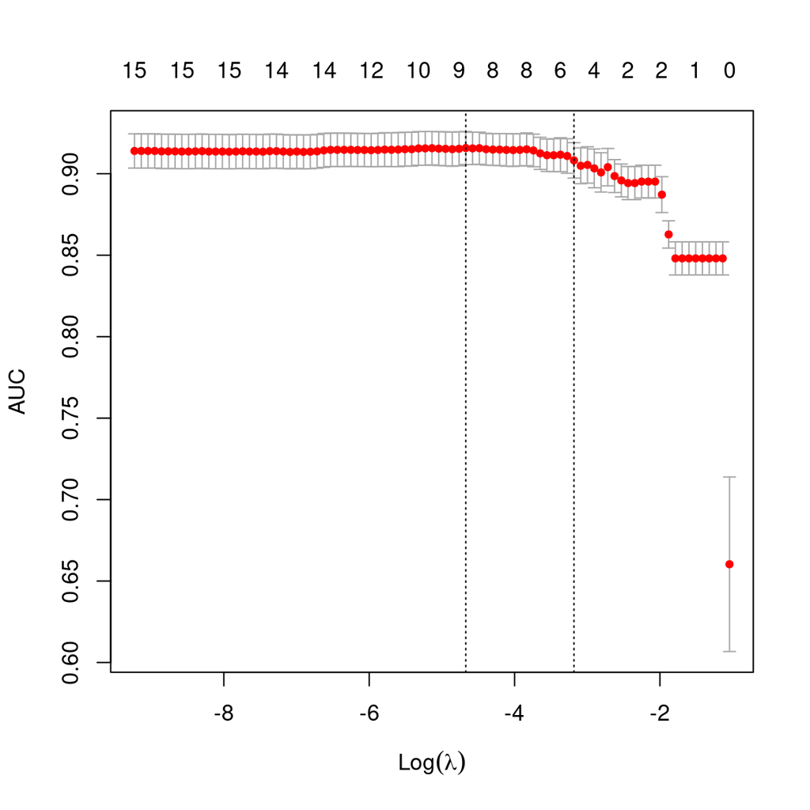

```r
# Para procesar en paralelo
registerDoParallel(cores=4)
# Entrenamos los modelos Cross Validation
cvfit_lasso = cv.glmnet(data.matrix(x_train), as.matrix(y_train), family = "binomial", alpha = 1, parallel = TRUE, type.measure='auc')
# Imprimimos el AUC para los diferentes alphas
plot(cvfit_lasso)
```

De los $\lambda$ mostrados anteriormente extraeremos los resultados para el $\lambda$ que arroje el menor error.

```r
rocplot <- function(pred, truth, ...) {
  predob = prediction(pred, truth)
  perf = performance(predob, "tpr", "fpr")
  plot(perf, ...)
  roc <- roc(pred, truth, auc=TRUE)
  area <- auc(roc)
  area <- format(round(area, 4), nsmall = 4)
  text(x=0.8, y=0.1, labels = paste("AUC =", area))

  # the reference x=y line
  segments(x0=0, y0=0, x1=1, y1=1, col="gray", lty=2)
}
# Extraemos las predicciones
pred_lasso = predict(cvfit_lasso, newx = data.matrix(x_test), s = "lambda.min", type = "class")
# Extraemos métricas generales
confusionMatrix(as.factor(pred_lasso), as.factor(y_test), positive="1")
```

```
## Confusion Matrix and Statistics
##
##           Reference
## Prediction  0  1
##          0 84  6
##          1  2  8
##
##                Accuracy : 0.92
##                  95% CI : (0.8484, 0.9648)
##     No Information Rate : 0.86
##     P-Value [Acc > NIR] : 0.04921
##
##                   Kappa : 0.6226
##
##  Mcnemar's Test P-Value : 0.28884
##
##             Sensitivity : 0.5714
##             Specificity : 0.9767
##          Pos Pred Value : 0.8000
##          Neg Pred Value : 0.9333
##              Prevalence : 0.1400
##          Detection Rate : 0.0800
##    Detection Prevalence : 0.1000
##       Balanced Accuracy : 0.7741
##
##        'Positive' Class : 1
##
```

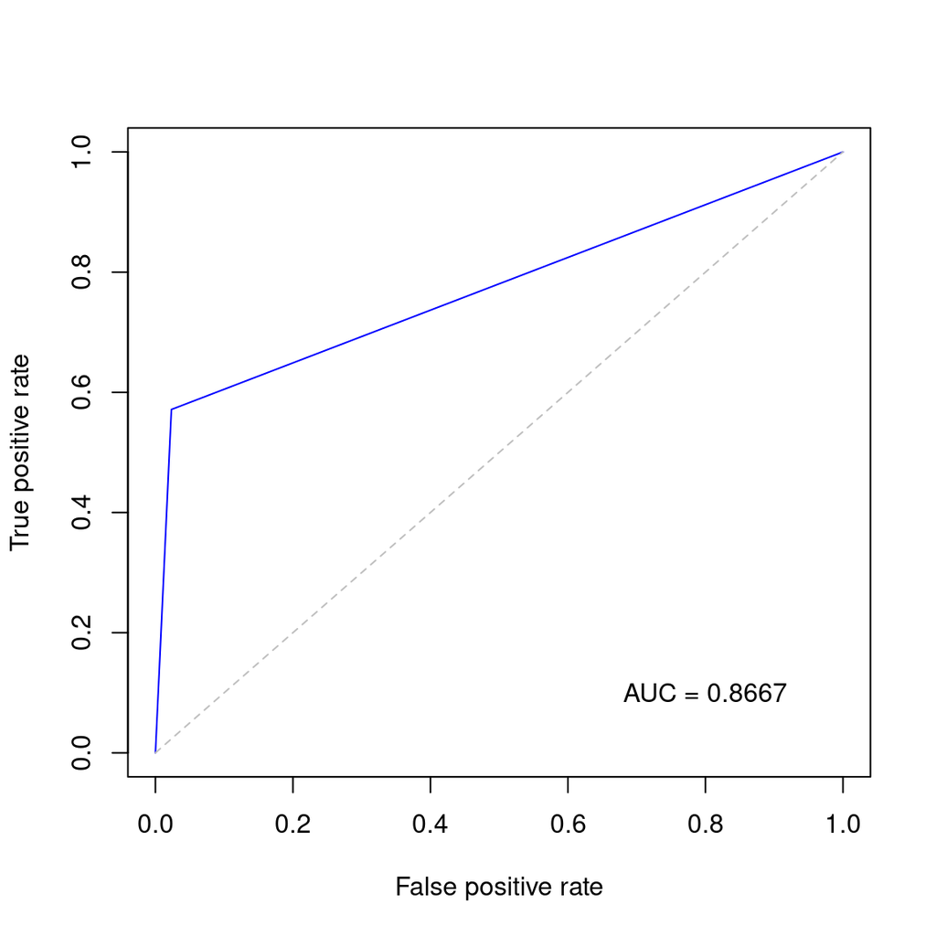

```r
# Extraemos AUC
rocplot(as.numeric(pred_lasso), y_test,col="blue")
```

## Ridge

Realizamos otra validación cruzada para diferentes $\lambda$ y mostraremos un gráfico con sus resultados. Para pasar de Lasso a Ridge simplemente tendremos que cambiar el alpha.

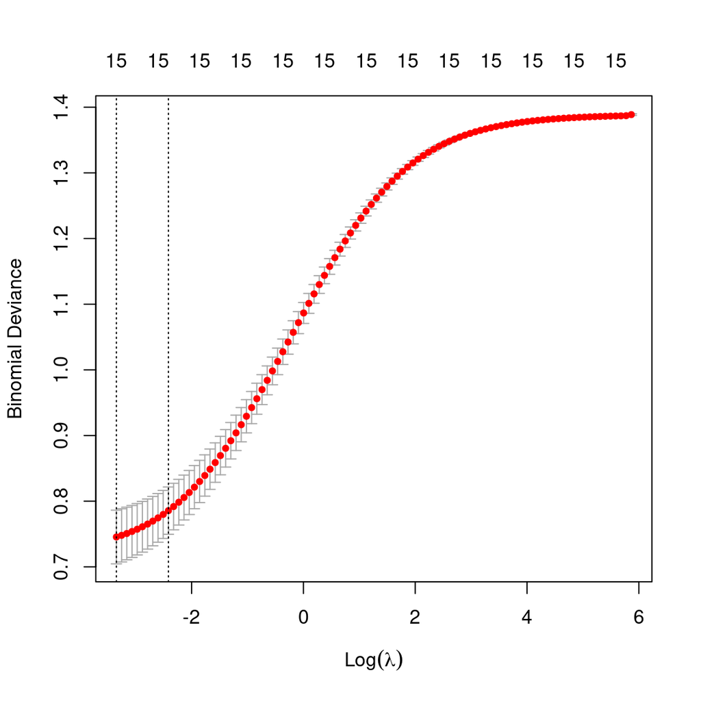

```r
# Entrenamos los modelos Cross Validation
cvfit_ridge = cv.glmnet(data.matrix(x_train), as.matrix(y_train), family = "binomial", alpha = 0, parallel=TRUE, standardize=TRUE)
# Imprimimos el AUC para los diferentes alphas
plot(cvfit_ridge)
```

De los $\lambda$ mostrados anteriormente extraeremos los resultados para el $\lambda$ que arroje el menor error.

```r
# Obtenemos la predicción
pred_ridge = predict(cvfit_ridge, newx = data.matrix(x_test), s = "lambda.min", type = "class", type.measur='auc')
# Extraemos métricas generales
confusionMatrix(as.factor(pred_ridge), as.factor(y_test), positive="1")
```

```
## Confusion Matrix and Statistics
##
##           Reference
## Prediction  0  1
##          0 84  7
##          1  2  7
##
##                Accuracy : 0.91
##                  95% CI : (0.836, 0.958)
##     No Information Rate : 0.86
##     P-Value [Acc > NIR] : 0.09224
##
##                   Kappa : 0.5605
##
##  Mcnemar's Test P-Value : 0.18242
##
##             Sensitivity : 0.5000
##             Specificity : 0.9767
##          Pos Pred Value : 0.7778
##          Neg Pred Value : 0.9231
##              Prevalence : 0.1400
##          Detection Rate : 0.0700
##    Detection Prevalence : 0.0900
##       Balanced Accuracy : 0.7384
##
##        'Positive' Class : 1
##
```

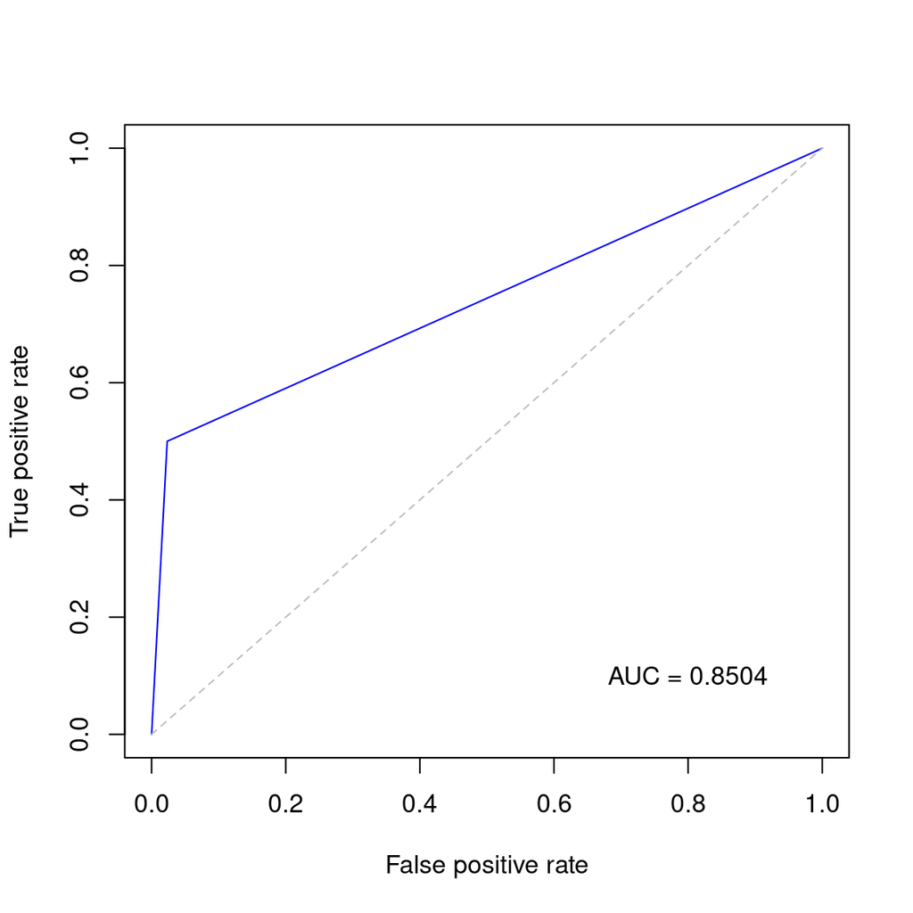

```r
# Extraemos AUC
rocplot(as.numeric(pred_ridge), y_test,col="blue")
```

## Resultados

Como podemos ver, la diferencia en los resultados entre Lasso y Ridge es muy leve. Para el caso de Ridge, hemos obtenido un AUC de 0.8504 y para Lasso tenemos un AUC de 0.8667.

# Ejercicio 5

Aporta los *log odds* de las variables predictoras sobre la variable objetivo.

Recordamos que hemos sustituido el símbolo de **+** con el número 1. Empezamos estudiando el caso del modelo Lasso.

```r
as.matrix(coef(cvfit_lasso, s = cvfit_lasso$lambda.1se))
```

```
##                         1
## (Intercept) -1.983635e+00
## A1           0.000000e+00
## A2           0.000000e+00
## A3           0.000000e+00
## A4          -8.651535e-02
## A5           0.000000e+00
## A6           0.000000e+00
## A7           0.000000e+00
## A8           4.725789e-03
## A9           2.763613e+00
## A10          6.632042e-01
## A11          2.860348e-02
## A12          0.000000e+00
## A13          0.000000e+00
## A14          0.000000e+00
## A15          1.804959e-05
```

Seguimos con el caso de los *log odds* en el caso de Ridge.

```r
as.matrix(coef(cvfit_ridge, s = cvfit_ridge$lambda.1se))
```

```
##                         1
## (Intercept) -1.108119e+00
## A1          -4.691551e-02
## A2           1.410092e-03
## A3           1.312708e-02
## A4          -2.964919e-01
## A5          -8.496063e-02
## A6           3.152786e-02
## A7           9.566341e-03
## A8           6.651336e-02
## A9           1.890695e+00
## A10          6.668375e-01
## A11          6.123645e-02
## A12         -2.524885e-02
## A13         -8.318695e-02
## A14         -6.745888e-04
## A15          4.243733e-05
```

# Ejercicio 6

Si por cada verdadero positivo ganamos 100e y por cada falso positivo perdemos 20e. ¿Qué valor monetario generará el modelo teniendo en cuénta la matriz de confusión del modelo con mayor AUC (con las métricas en test)?

Para el caso del modelo de Lasso

```r
m_lasso <- confusionMatrix(as.factor(pred_lasso), as.factor(y_test), positive="1")
m_lasso
```

```
## Confusion Matrix and Statistics
##
##           Reference
## Prediction  0  1
##          0 84  6
##          1  2  8
##
##                Accuracy : 0.92
##                  95% CI : (0.8484, 0.9648)
##     No Information Rate : 0.86
##     P-Value [Acc > NIR] : 0.04921
##
##                   Kappa : 0.6226
##
##  Mcnemar's Test P-Value : 0.28884
##
##             Sensitivity : 0.5714
##             Specificity : 0.9767
##          Pos Pred Value : 0.8000
##          Neg Pred Value : 0.9333
##              Prevalence : 0.1400
##          Detection Rate : 0.0800
##    Detection Prevalence : 0.1000
##       Balanced Accuracy : 0.7741
##
##        'Positive' Class : 1
##
```

```r
cat(c("Valor monetario que generará el modelo de Lasso es de: ", (m_lasso$table[[4]]*100)-(m_lasso$table[[2]]*20), "€"))
```

```
## Valor monetario que generará el modelo de Lasso es de:  760 €
```

```r
m_ridge <- confusionMatrix(as.factor(pred_ridge), as.factor(y_test), positive="1")
m_ridge
```

```
## Confusion Matrix and Statistics
##
##           Reference
## Prediction  0  1
##          0 84  7
##          1  2  7
##
##                Accuracy : 0.91
##                  95% CI : (0.836, 0.958)
##     No Information Rate : 0.86
##     P-Value [Acc > NIR] : 0.09224
##
##                   Kappa : 0.5605
##
##  Mcnemar's Test P-Value : 0.18242
##
##             Sensitivity : 0.5000
##             Specificity : 0.9767
##          Pos Pred Value : 0.7778
##          Neg Pred Value : 0.9231
##              Prevalence : 0.1400
##          Detection Rate : 0.0700
##    Detection Prevalence : 0.0900
##       Balanced Accuracy : 0.7384
##
##        'Positive' Class : 1
##
```

```r
cat(c("Valor monetario que generará el modelo de Ridge es de: ", (m_ridge$table[[4]]*100)-(m_ridge$table[[2]]*20), "€"))
```

```
## Valor monetario que generará el modelo de Ridge es de:  660 €
```

En estos términos podemos notar una diferencia mucho mas significativa entre los modelos estudiados.